# Data Pre-Processing for Machine Learning with Boston AirBnB data

Colin Pawlowski

8/28/2018

# 0. Introduction

Before we build our predictive models, we need to do a bit of wrangling to prepare our data set. Since this is a real-world example, we will need to deal with missing values and strange data types. Our goal will be to create a data frame with one column for the dependent variable, `price`, and the rest of the columns for the independent variables used to predict `price`, such as `# of bedrooms`, `# of bathrooms`, etc.

This file goes over some initial data pre-processing that we did to prepare the file `listingsML.RDS`, starting from the raw data file `listings.csv`. It is not required, but it may be helpful to look over this file to learn some data wrangling techniques for your future analytics projects in `R`. In addition, we have shared this code so that our data pipeline is transparent. It is important to document the steps in the data pipelines for all of your projects, so that the analysis can be replicated by yourself and others. First, let’s read in the data:

```r
library(tidyverse)
listingsOrig <- read.csv("../data/listings.csv", stringsAsFactors = FALSE)
```

# 1. Obtaining the Outcome Variable

This is the most important step of the data preparation process, because without historical data on AirBnB price, we cannot build a predictive model at all. Recall that the price column was originally in text format, so let’s convert to numeric format. Because this column is important, let’s make it the first column in our data frame.

```r
listingsML <- listingsOrig %>%
  mutate(price = as.numeric(gsub(",|\\$", "", price))) %>%
  select(price, everything())
```

Let’s take a look at our data set now.

```r
glimpse(listingsML)
```

```
## Observations: 3,585
## Variables: 95
## $ price                            <dbl> 250, 65, 65, 75, 79, 75, 100,...
## $ id                               <int> 12147973, 3075044, 6976, 1436...
## $ listing_url                      <chr> "https://www.airbnb.com/rooms...
## $ scrape_id                        <dbl> 2.016091e+13, 2.016091e+13, 2...
## $ last_scraped                     <chr> "2016-09-07", "2016-09-07", "...
## $ name                             <chr> "Sunny Bungalow in the City",...
## $ summary                          <chr> "Cozy, sunny, family home.  M...
## $ space                            <chr> "The house has an open and co...
## $ description                      <chr> "Cozy, sunny, family home.  M...
## $ experiences_offered              <chr> "none", "none", "none", "none...
## $ neighborhood_overview            <chr> "Roslindale is quiet, conveni...
## $ notes                            <chr> "", "If you don't have a US c...
## $ transit                          <chr> "The bus stop is 2 blocks awa...
```

[output cut: 82 more lines]

# 2. Converting Data Types of Independent Variables

Just as we differentiate between regression / classification for continuous / categorical outcome variables, we should differentiate between continuous / categorical independent variables when preparing our data set for machine learning. `R` tries to do this automatically when it reads in the data set, but sometimes it makes mistakes. For example, `host_response_rate` should be numeric data type and `last_scraped` should be a date data type. In addition, "N\A" and "" should be marked as missing values. Let’s make these changes, learning some more tidyverse commands in the process:

```r
# Step 1: convert "N/A" and "" to NA values
# Step 2: convert (last_scraped, host_since, first_review, last_review,
#         calendar_last_scraped) to Date format
# Step 3: convert (host_response_rate, host_acceptance_rate,
#         weekly_price, monthly_price, security_deposit,
#         cleaning_fee, extra_people) to numeric format
listingsML <- listingsML %>%
  mutate_all(~na_if(., "N/A")) %>%
  mutate_all(~na_if(., "")) %>%
  mutate_at(vars(last_scraped, host_since, first_review, last_review,
                 calendar_last_scraped), as.Date) %>%
  mutate_at(vars(host_response_rate, host_acceptance_rate,
                 weekly_price, monthly_price, security_deposit,
                 cleaning_fee, extra_people),
            ~as.numeric(gsub("\\%|\\$", "", .)))
```

It looks like most of the columns are in the correct format except for `amenities`, which we will look at next.

**Side note about custom functions:** There are few ways to write custom functions in R. Here is the notation for the function f(x) = x^2.

```r
f <- function(x) {
  return(x ^ 2)
}
```

Alternatively, we can write this function more compactly as:

```r
f <- function(x) x ^ 2
```

In dplyr, another way of writing functions instead of "function(x) <code here with x as a variable>" is "~ <code here with . as a variable>". So if we wanted to square the price column we could write:

```r
listings2 <- listingsML %>%
  mutate_at(vars(price), ~ . ^ 2)
```

Let’s remove these new variables we just created to clean up our environment:

```r
rm(listings2)
rm(f)
```

# 3. Missing Value Imputation

Missing values are a nuisance which must be handled early on to avoid causing problems downstream in the data pipeline. In `R`, missing values take the value `NA`. They may be caused by a number of different factors, which should influence how we deal with them. First off, let’s check how many missing values are in each column of our data set.

```r
listingsML %>%
  is.na() %>%
  colSums() %>%
  sort(decreasing = T)
```

```
##     neighbourhood_group_cleansed                 has_availability
##                             3585                             3585
##                          license               jurisdiction_names
##                             3585                             3585
##                    monthly_price                      square_feet
##                             3541                             3529
##                     weekly_price                 security_deposit
##                             3009                             2317
##                            notes                      interaction
##                             1975                             1554
##                           access            neighborhood_overview
##                             1489                             1415
##                       host_about                          transit
##                             1309                             1290
##                      house_rules                     cleaning_fee
##                             1192                             1107
##                            space           review_scores_accuracy
##                             1057                              823
##           review_scores_location              review_scores_value
##                              822                              821
##            review_scores_checkin        review_scores_cleanliness
##                              820                              818
##      review_scores_communication             review_scores_rating
##                              818                              813
##                     first_review                      last_review
##                              756                              756
##                reviews_per_month                    thumbnail_url
##                              756                              599
##                       medium_url                   xl_picture_url
##                              599                              599
##                    neighbourhood               host_response_time
##                              543                              471
##               host_response_rate             host_acceptance_rate
##                              471                              471
##               host_neighbourhood                          summary
##                              339                              143
##                          zipcode                           market
##                               38                               14
##                        bathrooms                    host_location
##                               14                               11
```

[output cut: 41 more lines]

```
##                                0                                0
##                 calendar_updated                  availability_30
##                                0                                0
##                  availability_60                  availability_90
##                                0                                0
##                 availability_365            calendar_last_scraped
##                                0                                0
##                number_of_reviews                 requires_license
##                                0                                0
##                 instant_bookable              cancellation_policy
##                                0                                0
##    require_guest_profile_picture require_guest_phone_verification
##                                0                                0
##   calculated_host_listings_count
##                                0
```

It looks like some columns are missing all 3585 values! We definitely want to remove these from our data set, because they are giving no useful information. Let’s remove all columns with 90% or more missing values. For the rest of the columns, we will use missing value imputation to “fill in” the unknown values with their most likely values. There are many good R packages for this, for example `mice` for multiple imputation or `missForest` for random forest imputation. Here, we will do a simple median imputation.

```r
# Step 1: Remove columns with 90% or more missing values
# Step 2: Fill in missing values in numeric columns with the median value
# (We may need to convert integer to numeric types if we impute fractional values)
# Step 3: Fill in missing values in categorical columns with the value "UNKNOWN"
listingsML <- listingsML %>%
  select_if(~sum(is.na(.)) < 0.9 * nrow(listingsOrig)) %>%
  mutate_if(is.integer, as.numeric) %>%
  mutate_if(~is.numeric(.) | is.double(.), ~coalesce(., median(., na.rm = T))) %>%
  mutate_if(is.character, ~coalesce(., "UNKNOWN"))
```

# 4. Expand the Amenities and Host Verifications

Let’s take a look at the `amenities` column in the data set.

```r
listingsML$amenities[1:3]
```

```
## [1] "{TV,\"Wireless Internet\",Kitchen,\"Free Parking on Premises\",\"Pets live on this property\",Dog(s),Heating,\"Family/Kid Friendly\",Washer,Dryer,\"Smoke Detector\",\"Fire Extinguisher\",Essentials,Shampoo,\"Laptop Friendly Workspace\"}"
## [2] "{TV,Internet,\"Wireless Internet\",\"Air Conditioning\",Kitchen,\"Pets Allowed\",\"Pets live on this property\",Dog(s),Heating,\"Family/Kid Friendly\",Washer,Dryer,\"Smoke Detector\",\"Carbon Monoxide Detector\",\"Fire Extinguisher\",Essentials,Shampoo,\"Lock on Bedroom Door\",Hangers,\"Hair…
## [3] "{TV,\"Cable TV\",\"Wireless Internet\",\"Air Conditioning\",Kitchen,\"Free Parking on Premises\",Heating,Washer,Dryer,\"Smoke Detector\",\"Carbon Monoxide Detector\",\"First Aid Kit\",\"Safety Card\",Essentials,Shampoo,\"Lock on Bedroom Door\",\"translation missing: en.hosting_amenity_49\",\…
```

Although it is listed as a single variable, this is really multiple categorical variables grouped together. We will use the following custom-made function to split this into multiple columns.

```r
expand_amenities <- function(listings_df) {
  listings_df <- listings_df %>%
    mutate(amenities = gsub("[{}]|\"|[()]|-", "", paste(amenities))) %>%
    mutate(amenities = gsub(" |/", "_", amenities)) %>%
    mutate(amenities = gsub("24", "x24", amenities)) %>%
    mutate(amenities = gsub("translation_missing:_en.hosting_amenity",
                            "other", amenities))

  splitting <- strsplit(listings_df$amenities, ",")
  all_amenities <- Reduce(union, splitting)
  for (i in all_amenities) {
    listings_df[paste0("amenity_", i)] <-
      grepl(i, listings_df$amenities)
  }
  return(listings_df)
}
```

We can write a similar function to expand the `host_verifications` column into multiple columns.

```r
expand_hostVerifications <- function(listings_df) {
  listings_df <- listings_df %>%
    mutate(host_verifications = gsub("'|\\[|\\]| ", "", paste(host_verifications)))

  splitting <- strsplit(listings_df$host_verifications, ",")
  all_verifications <- Reduce(union, splitting)
  for (i in all_verifications) {
    listings_df[paste0("host_", i)] <-
      grepl(i, listings_df$host_verifications)
  }
  return(listings_df)
}
```

Let’s split the columns and take a look:

```r
listingsML <- listingsML %>%
  expand_amenities() %>%
  expand_hostVerifications()
glimpse(listingsML)
```

```
## Observations: 3,585
## Variables: 147
## $ price                              <dbl> 250, 65, 65, 75, 79, 75, 10...
## $ id                                 <dbl> 12147973, 3075044, 6976, 14...
## $ listing_url                        <chr> "https://www.airbnb.com/roo...
## $ scrape_id                          <dbl> 2.016091e+13, 2.016091e+13,...
## $ last_scraped                       <date> 2016-09-07, 2016-09-07, 20...
## $ name                               <chr> "Sunny Bungalow in the City...
## $ summary                            <chr> "Cozy, sunny, family home. ...
## $ space                              <chr> "The house has an open and ...
## $ description                        <chr> "Cozy, sunny, family home. ...
## $ experiences_offered                <chr> "none", "none", "none", "no...
## $ neighborhood_overview              <chr> "Roslindale is quiet, conve...
## $ notes                              <chr> "UNKNOWN", "If you don't ha...
## $ transit                            <chr> "The bus stop is 2 blocks a...
```

[output cut: 134 more lines]

We have increased the number of variables from 89 to 147 in the data set, with new features such as `amenity_TV`, `amenity_Wireless_Internet`, and `amenity_Kitchen`, along with `host_email`, `host_phone`, and `host_facebook`. These features should be predictive of price, so we think that these will improve our machine learning models.

# 5. Remove Extra Variables

There are some variables, such as `description` and `listing_url`, which are categorical variables that are not going to be useful in our predictive model because they have too many or too few levels. Other variables such as `weekly_price` and `cleaning_fee` may be highly predictive of price, but we would like to build models without this information so that it will be more useful in practice. Other variables such as `neighborhood` may be removed because they are redundant (there is a `neighborhood_cleansed` variable). In this part, let’s remove all of the extra independent variables that we will not include in our machine learning model to predict price.

```r
# Step 1: Remove categorical variables with too many levels
# Step 2: Remove categorical variables with only 1 level
# Step 3: Remove redundant variables
listingsML <- listingsML %>%
  select_if(~!is.character(.) || length(unique(.)) < 100) %>%
  select(-id, -host_id) %>%
  select_if(~length(unique(.)) > 1) %>%
  select(-weekly_price, -security_deposit, -cleaning_fee) %>%
  select(-neighbourhood, -city, -zipcode, -market,
         -smart_location, -host_verifications,
         -host_neighbourhood, -calendar_updated)
glimpse(listingsML)
```

```
## Observations: 3,585
## Variables: 103
## $ price                              <dbl> 250, 65, 65, 75, 79, 75, 10...
## $ host_since                         <date> 2015-04-15, 2012-06-07, 20...
## $ host_response_time                 <chr> "UNKNOWN", "within an hour"...
## $ host_response_rate                 <dbl> 100, 100, 100, 100, 100, 10...
## $ host_acceptance_rate               <dbl> 94, 100, 88, 50, 100, 95, 9...
## $ host_is_superhost                  <chr> "f", "f", "t", "f", "t", "t...
## $ host_listings_count                <dbl> 1, 1, 1, 1, 1, 2, 5, 2, 1, ...
## $ host_total_listings_count          <dbl> 1, 1, 1, 1, 1, 2, 5, 2, 1, ...
## $ host_has_profile_pic               <chr> "t", "t", "t", "t", "t", "t...
## $ host_identity_verified             <chr> "f", "t", "t", "f", "t", "t...
## $ neighbourhood_cleansed             <chr> "Roslindale", "Roslindale",...
## $ latitude                           <dbl> 42.28262, 42.28624, 42.2924...
## $ longitude                          <dbl> -71.13307, -71.13437, -71.1...
```

[output cut: 90 more lines]

# 6. Creating Factor Variables

Currently, all of our categorical variables are encoded as character data types, but we would like them to be encoded as factors. In addition, we would like to get rid of the very rare categories (those with frequency < 1%) and group them into a single "other" category. We can do this using the `fct_lump` function.

```r
# Step 1: Convert categorical variables from character to factor data types
# Step 2: Lump least common (< 1% frequency) categories in the factor variables together
#         into one "other" category
listingsML <- listingsML %>%
  mutate_if(is.character, as.factor) %>%
  mutate_if(is.factor, ~fct_lump(., prop = 0.01))
```

# 7. Removing Outliers

This step is not strictly necessary, but we will do it for this example.  
Take a look at the relationship between `listings$accommodates` and `listings$price`.

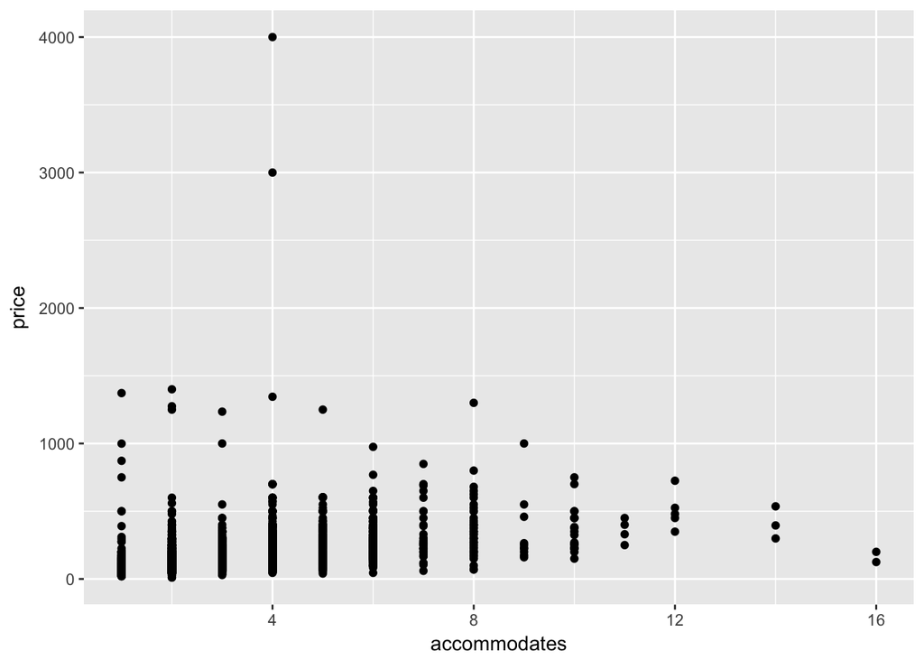

```r
ggplot(data = listingsML) +
  geom_point(aes(x = accommodates, y = price))
```

Looks like there are some outliers on both axes. There are fancier ways to deal with this statistically, but for today let’s just get rid of the outliers.

```r
listingsML <- listingsML %>%
  filter(accommodates <= 10, price <= 1000)
```

# 8. Save the Result

Finally, let’s save the pre-processed data set that we have made. The best way to save it is as an RDS file, which is a format recognized by `R` and is fast to read/write.

```r
saveRDS(listingsML, "../data/listingsML.RDS")
```